# Lab 9 - building an R package

In this lab we’ll learn how to create an R package that can be installed and used like any other R package.

Feel free to refer to https://github.com/lvclark/SNPfreq, which has a working version of the package in this example.

## Setting up a GitHub repository for your R package

You can, of course, just keep a copy of your R package on your local computer while you work on it. However there are a few advantages to putting it on GitHub.

- You have a backup of all your work, and it’s very simple to keep the backup up-to-date
- You can edit your package from any computer with RStudio and Git installed (home, computer lab, office, etc.)
- Allows multiple people to work on one R package and see each other’s changes
- You can share your package with anyone just by sending them a link
- Other people can discover your package, try it out, and give you feedback
- You can get a DOI so you can cite your package in a manuscript

Log in to GitHub.com and create a new repository, initialized with a README file. In these examples I’ll call the package `SNPfreq` and use some previous code that I wrote in class for working with SNP allele frequencies. However, feel free to use your own code or other code from class, and name your repository something that makes sense.

Now in RStudio, go to File -> New Project -> Version Control -> Git. Enter the URL for the repository that you just created on GitHub, and the folder on your computer where you want the package to do.

## Setting up the package structure

Within the folder for your package, you need to make a folder called “R” and a folder called “man”. There are others that you may add later, but these two are mandatory. “R” will contain all of the R code defining the functions (and possibly classes and methods) for your package. These will be normal, text .R files like we have alredy been creating in class. “man” will contain .Rd files documenting your functions.

There are a couple ways to create these folders. Directly in RStudio, you can go to the Files pane and click “New Folder”. You could also navigate to your package folder in Windows Explorer (on Windows) or Finder (on a Mac) and make the folders there.

You will also need to create two mandatory files. These will be called “DESCRIPTION” and “NAMESPACE” and won’t have any file extension at the end. In RStudio go to File -> New File -> Text File to create two new files, then save them into these two names. You don’t have to put anything into them yet.

Git and RStudio have added some extra files and directories to the folder, which you will not actually want when you go to build and install the package. To make R package tools ignore those files, create a new text file called “.Rbuildignore”. Each line of this file is a regular expression indicating a file name to ignore. Put the following lines into the file:

```
^\.git$
^\.Rproj\.user$
^\.gitattributes$
^\.gitignore$
^README\.md$
^.*\.Rproj$
^\.Rhistory$
^\.RData$
^LICENSE$
```

Save the file. Go into the Git menu to review everything you have added, and make your first commit. Go into the Git menu again to push the commit, and check your repository page on github.com to see that the new folders and files have shown up.

Here’s a snapshot of what your package folder should look like (approximately) at this point:

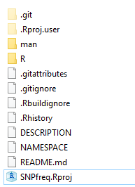

R package structure

## Adding your R code

Open up the file “GGSNP_abstraction_example.R”, or another file of your choice where you have defined some R functions. Delete everything that isn’t a function definition. You can leave comments. For example, you want to delete the calls to `setwd` and `load`, and the lines that were used for trying out the functions. Save the file into your “R” directory in the package, and give it a name that makes sense, for example “SNPfreq_functions.R”.

Run `source` on the file to load all of the functions into your global environment, and to check that there aren’t any errors.

Perhaps do another commit here, or wait until more changes have been made if you prefer.

## Documenting the functions

Use `prompt` to make a skeleton .Rd file for one of your functions. For example:

```r
prompt(minorAlleleFrequency)
```

There should now be a file called “minorAlleleFrequency.Rd” (or a different name if you did this for a different function). Either in the RStudio Files pane or in your operating system’s file explorer, move this file into the “man” directory. Open the file in RStudio.

If you are using the SNP allele frequency example, this is a good case where you can document multiple functions in one .Rd file. They all do related things, and they all have an argument called `SNPmat` that accepts a matrix of the same format.

To make this .Rd file document all three functions, add

```
\alias{filterSNPs}
\alias{mafHist}
```

under the existing line `\alias{minorAlleleFrequency}`.

You will also need to add usage lines for the other two functions. These can go into the same `\usage` section as `minorAlleleFrequency`.

```
\usage{
minorAlleleFrequency(SNPMat)
filterSNPs(SNPmat, minMAF = 0.05)
mafHist(SNPmat)
}
```

In the `\arguments` section, you will see a spot where you can describe the `SNPmat` argument. Add another item for the `minMAF` argument, and fill in a description there as well.

Add a title into the `\title` section. This should be in title case, i.e. most words are capitalized. Add a sentence or two describing what the functions do.

In the `\value` section, describe separately what each function returns. For example, `minorAlleleFrequency` returns a vector of allele frequencies, `filterSNPs` returns a SNP matrix in the same format as `SNPmat` but with columns removed for SNPs with very rare alleles, and `mafHis` draws a plot and doesn’t return anything.

If you have more to say about the functions, you can write it in the `\details` section, but otherwise that section can be deleted. You can put your name in the `\author` section, or delete that section. In this case we can delete the `\references` section since we don’t have any articles or websites related to the functions. `\seealso` will be helpful if we put any other functions into the package, but since we haven’t done that yet we can comment that section out with the `%` character. You can delete the `\keyword` sections and the `\note` section.

In the `\examples` section, delete the function definition. In this section, add some code demonstrating use of all three functions. First, add a call to `matrix` to make a very small matrix to be passed to the `SNPmat` argument. The entire chunk of code in this section should run on its own without needing any other objects from the global environment.

Save your .Rd file and hit the “Preview” button to see what it will look like in RStudio. If there are problems with the syntax (a missing curly brace, etc.) you may get an error. Fix the file up so that it compiles and looks how you want it to look, then save it and make a commit.

## Package namespace

Open up your NAMESPACE file again. Add the line:

```
export(minorAlleleFrequency, filterSNPs, mafHis)
```

What is this telling R? This `export` statement means that when the package is loaded, those three functions should become available to the user. If you want to have some **internal functions**, i.e. functions that are called by other functions in your package but that aren’t accessible to the user, you can omit them from the `export` statement.

There are a few other things that you may need in the NAMESPACE file. Later when you run the package check you may get a message that you need to add an `importFrom` statement. Just copy it straight out of the package check log and add it to your NAMESPACE file. This happens if your functions use some functions outside of the R “base” package, for example any functions in the “stats” package (which we take for granted being available every time R starts up).

If you define any new S3 methods, you will need a line like

```
S3method(fn, cls)
```

for each, where “fn” is the name of the function and “cls” is the name of the class. If you use the S4 system, you will instead need `exportClasses` and `exportMethods` statements.

## Package description

Lastly you need a DESCRIPTIOn file. If you go to http://mirror.las.iastate.edu/CRAN/doc/manuals/r-release/R-exts.html#The-DESCRIPTION-file you will see a pretty thorough explanation of what needs to be in there. It will contain information about what the package is called, what it does, what version it is, who you are, and what other packages are required for using it.

Here is an example of what your DESCRIPTION file might look like:

```
Package: SNPfreq
Version: 0.0
Date: 2017-11-14
Title: SNP Allele Frequency Estimation and Utilities
Authors@R: person("Lindsay", "Clark", role = c("aut", "cre"),
                  email = "lvclark@illinois.edu")
Author: Lindsay Clark [aut, cre]
Maintainer: Lindsay Clark <lvclark@illinois.edu>
Description: This package includes functions to estimate minor allele frequencies
  from numerical SNP data, plot histograms of minor allele frequencies, and
  filter SNP data based on minor allele frequencies.
Url: https://github.com/lvclark/SNPfreq
License: GPL-3
```

If your package needs functions from other packages in order to run, you should list those packages in a line that starts with `Imports:`. If there are other packages that might be useful together with your package but are not strictly necessary for using it, list them under `Suggests:`.

Note the indentation in the `Description:` field. If correct indentation is not used, it will cause problems with the package check.

If you list a standard license in the `License:` field, you don’t need a separate LICENSE file. If you have one (for example, automatically added by GitHub), either delete it or add it to .Rbuildignore.

## Building and checking the package

Now we have the bare minimum to make the package installable. To make a file that we can install from, we’ll **build**. There are point-and-click tools in the upper right of RStudio for building, or you can type the following into your Terminal:

```
cd ..
R CMD build SNPfreq --no-manual
```

Once the package builds, either **check** it using the tools in the upper right, or in the Terminal type the command:

```
R CMD check SNPfreq_0.0.tar.gz --no-manual
```

Here we are using `--no-manual` because we don’t have a LaTeX compiler installed on the lab computers. On Windows I recommend MikTeX for this purpose. It will let you see what your help pages will look like in PDF form.

If there are errors, warnings, or notes, fix the package, then rebuild it and check it again.

Once it is passing the package checks, it’s a great time to make a commit. Your first working version of the package!

Now you can install the package with:

```
R CMD INSTALL SNPfreq_0.0.tar.gz
```

Alternatively, within R you can install it with:

```r
install.packages("SNPfreq_0.0.tar.gz", repos = NULL)
```

If you are on Windows, and you want to make a binary version of the package that someone can install without needing Rtools, run:

```
R CMD INSTALL SNPfreq_0.0.tar.gz --build
```

This will make a zip file, that can be installed within R:

```r
install.packages("SNPfreq_0.0.zip", repos = NULL)
```

If you are on a Mac or Linux machine and you want to make a binary of your package for Windows, there is a web service that will do it for you: https://win-builder.r-project.org/

The binary files `SNPfreq_0.0.tar.gz` and `SNPfreq_0.0.zip` can be attached when you make a release on GitHub. That way, someone can easily download an installable version of your package.

Regardless of what method you have used for installing the package, you should now be able to load it in R:

```r
library(SNPfreq)
```

Check out the help file that you wrote:

```r
?mafHist
```

Of course, the functions themselves should now be available, and you should see the SNPfreq environment in your drop-down list of environments.

**Question to turn in:** Give me the URL to your R package, which should build and pass the package check.

## Making a vignette – for homework or if you have extra time

Let’s make a vignett with R Markdown In your package directory, make a new directory called “vignettes”.

In RStudio, make a new “R Markdown” file. Save it into the “vignettes” directory, and give it some name with the .Rmd extension. In the file header, after “Title”," “Author”, “Date”, and “Output” and before the closing `---`, add:

```
vignette: >
  %\VignetteEngine{knitr::rmarkdown}
  %\VignetteIndexEntry{A Tutorial for SNPfreq}
```

After a section header (`##`), write up a little explanation of what one of the functions does.

Next to the “Run” button you’ll see a little “+C” button. Click it to add a code chunk. Now in that code chunk you can write some R code. Like the examples in your .Rd file, everything in the vignette will need do be executable on its own. However, you can put some data files into the “vignettes” directory for the vignette code to read, for example by `load` or `read.table`. For example we could put the “GGSNPs.RData” file into the “vignettes” directory if we wanted to be able to load it in the vignette.

````
 ```{r}
 library(SNPfreq)
 load("GGSNPs.RData")
 myMAF <- minorAlleleFrequency(GGdata)
 myMAF
 ```
````

Now click “Knit”. You should get a nice HTML version of your tutorial.

You can probably add the HTML file to your .gitignore and .Rbuildignore files, since you will only need to track changes to the original R Markdown, the R build command will rebuild the HTML anyway, and GitHub won’t display a rendered version of the HTML.

You’ll also have to modify the DESCRIPTION file to indicate that `knitr` is used for making the vignette. Add the line `Imports: knitr`, or add knitr to the list if you already have an `Imports` line. Also add the line `VignetteBuilder: knitr`.

Build and check your package again. If there are any issues with the vignette, it will let you know, and you can fix them. Once the package is installed, in the directory where it is installed there will be a `doc` directory with your vignette. To prevent a note in your package check, you may need to also add a line like `importFrom("knitr", "knit2html")` to the NAMESPACE file.

## Including a dataset in a package (also if you have extra time)

You put an `.RData` file into the `vignettes` directory for building the vignette, but what if you want the user to have access to a dataset? This can be handy so that they can follow along with the vignette and with the examples in the man pages. Or, you might use an R package to distribute a real dataset that many people would need for their analysis.

Take `GGSNPs.RData`, and rename it `GGdata.RData` so the file and object name match. Now make a directory in your package called `data`, and move the `.RData` file there. Then run

```r
promptData(GGdata)
```

You’ll get a file called `GGdata.Rd` that you can move into your `man` directory and edit to make a help page for the dataset.

Then, in your vignette, you can change your code chunk to be:

````
 ```{r}
 library(SNPfreq)
 data(GGdata)
 myMAF <- minorAlleleFrequency(GGdata)
 myMAF
 ```
````

You can also now call `data(GGdata)` in the Examples section of your help page(s) in the `man` folder.

## A different way to include a dataset in a package (also if you have extra time)

If you want to have a dataset accessible in a different file format (like a CSV), make a folder in your package directory called `inst`. Anything in this folder will be installed with the package; you could put in any custom files you wanted here. The standard is to make a folder inside of `inst` called `extdata`. There you can put files for datasets.

Once the package is installed, you can get a path to where the file is with

```r
mypath <- system.file("extdata", "myfile.txt", package = "mypackage")
```

where the second and third arguments are changed accordingly. To access the file in your examples and vignettes, use `system.file`, which will ensure that the path will work on someone else’s computer.